# **Reducing Greenhouse Gas Emissions** Where Are Efforts Best Focused?

Adam Englund

# 1 **Abstract**

# 2 **Introduction**

# 3 **Data**

The data provided has been extracted from global development data made available by the World Bank Group, it is comprised of indicators that were categorized under the topic of climate change.

Since the goal is to try to determine what contributes the greatest impact to greenhouse gas emissions, the variable ‘EN.ATM.GHGT.KT.CE’ (total greenhouse gas emissions as kt of CO2 equivalent) was initially chosen as the response variable. However, it was decided that a per capita measure of emissions is a fairer way to compare nations. So a new variable was created for this called ‘EN.ATM.GHGT.KT.PC’ (while trying to use the same naming convention) calculated by dividing ‘EN.ATM.GHGT.KT.CE’ by the total population (‘SP.POP.TOTL’).

To aid in some visualization, some other variables was created:

```r
# create variable for total greenhouse gas emissions per capita as kt of CO2 equivalent
wbcc_cln$EN.ATM.GHGT.KT.PC <- wbcc_cln$EN.ATM.GHGT.KT.CE/wbcc_cln$SP.POP.TOTL
# get the quantiles of EN.ATM.GHGT.KT.PC
q <- quantile(wbcc_cln$EN.ATM.GHGT.KT.PC, probs=seq(0, 1, 0.25))
# set to low, med, high or very high for 1st, 2nd , 3rd and 4th quantile respectively
wbcc_cln$EN.ATM.GHGT.CLS.PC <- ifelse(wbcc_cln$EN.ATM.GHGT.KT.PC <= q[1], 'Low',
                                   ifelse(wbcc_cln$EN.ATM.GHGT.KT.PC <= q[2], 'Medium',
                                          ifelse(wbcc_cln$EN.ATM.GHGT.KT.PC <= q[3], 'High', 'Very High')))
# convert new variable to factor
wbcc_cln$EN.ATM.GHGT.CLS.PC <- factor(wbcc_cln$EN.ATM.GHGT.CLS.PC,
                                   levels=c("Low","Medium","High","Very High"))

# create variable for % of electricity generated by fossil fuels
EG.ELC.FOSS.PC <- round(apply(wbcc_cln[c('EG.ELC.COAL.ZS', 'EG.ELC.NGAS.ZS', 'EG.ELC.PETR.ZS')],
                              1, FUN=sum), 8)
# get the quantiles of EG.ELC.FOSS.PC
q <- quantile(EG.ELC.FOSS.PC, probs=seq(0, 1, 0.25))
# set to low, med, high or very high for 1st, 2nd , 3rd and 4th quantile respectively
wbcc_cln$EG.ELC.FOSS.CLS <- ifelse(EG.ELC.FOSS.PC <= q[1], 'Low',
                                   ifelse(EG.ELC.FOSS.PC <= q[2], 'Medium',
                                          ifelse(EG.ELC.FOSS.PC <= q[3], 'High', 'Very High')))
# convert new variable to factor
wbcc_cln$EG.ELC.FOSS.CLS <- factor(wbcc_cln$EG.ELC.FOSS.CLS,
                                   levels=c("Low","Medium","High","Very High"))
```

The dataset required further cleaning as there were a number of missing values that affected the majority of the dataset, there were many indicators that were reflecting the same information, and there were also indicators that were clearly not relevant to the planned analysis. To handle removal of the indicators for the previously stated reasons, the indicators were sorted according to which had the largest number of missing values (please refer to Appendix B Part I). This prioritized the order in which the indicators were considered to be surplus to requirements. Appendix B Part II contains the full list of the indicators that were removed, it was considered appropriate to use a mixture of energy usage indicators, natural resource usage indicators, and some economic indicators as the predictors for greenhouse gas emissions, and the reasons for keeping or removing a variable were based on this logic as well as whether a variable was duplicating information.

It was also decided to convert the electricity production indicators from percentages to kilowatts per hour. This was done by multiplying ‘EG.USE.ELEC.KH.PC’ (electric power consumption kWh per capita) by the percentage indicators for different energy sources (i.e. ‘EG.ELC.COAL.ZS’, ‘EG.ELC.NUCL.ZS’ etc.). This was then taken a step further to break down the predictor ‘EG.USE.PCAP.KG.OE’ (energy use kg of oil equivalent per capita) into energy use from electricity and other forms of energy usage. This was done by first converting ‘EG.USE.PCAP.KG.OE’ from units in kg of oil equivalent to units in kWh (at a ratio of 1:11.63) to match the units used by ‘EG.USE.ELEC.KH.PC’. ‘EG.USE.ELEC.KH.PC’ was then subtracted from the converted value of ‘EG.USE.PCAP.KG.OE’ (in kWh) to create a new predictor called ‘EG.USE.OTHR.KH.PC’ (energy use from source other than electricity kWh per capita).

```r
wbcc_cln$EG.USE.OTHR.KH.PC <- wbcc_cln$EG.USE.PCAP.KG.OE*11.63 - wbcc_cln$EG.USE.ELEC.KH.PC
wbcc_cln$EG.ELC.COAL.KH.PC <- wbcc_cln$EG.ELC.COAL.ZS * wbcc_cln$EG.USE.ELEC.KH.PC
wbcc_cln$EG.ELC.HYRO.KH.PC <- wbcc_cln$EG.ELC.HYRO.ZS * wbcc_cln$EG.USE.ELEC.KH.PC
wbcc_cln$EG.ELC.NGAS.KH.PC <- wbcc_cln$EG.ELC.NGAS.ZS * wbcc_cln$EG.USE.ELEC.KH.PC
wbcc_cln$EG.ELC.NUCL.KH.PC <- wbcc_cln$EG.ELC.NUCL.ZS * wbcc_cln$EG.USE.ELEC.KH.PC
wbcc_cln$EG.ELC.PETR.KH.PC <- wbcc_cln$EG.ELC.PETR.ZS * wbcc_cln$EG.USE.ELEC.KH.PC
wbcc_cln$EG.ELC.RNWX.KH.PC <- wbcc_cln$EG.ELC.RNWX.ZS * wbcc_cln$EG.USE.ELEC.KH.PC
wbcc_cln$EG.ELC.RNEW.KH.PC <- wbcc_cln$EG.ELC.RNWX.ZS + wbcc_cln$EG.ELC.HYRO.KH.PC
wbcc_cln$EG.ELC.FOSS.KH.PC <- wbcc_cln$EG.ELC.COAL.KH.PC + wbcc_cln$EG.ELC.NGAS.KH.PC + wbcc_cln$EG.ELC.PETR.KH.PC
```

At the end of this process there were 16 indicators and 130 countries left from the original dataset, as described in the table below.

[output not shown]

# 4 **Methods**

Some exploratory analysis was initially conducted, first using a simple scatter plot to view the most obvious relationship, and then using principal component analysis and k-means clustering to try to determine whether patterns or relationships exist in the higher dimensional data we have. This revealed some evidence of some interesting relationships within data, from there linear regression was performed with feature selection to determine a model that would allow us to compare the relative impact of the most important predictors on the response. More detailed information for each of these steps is outlined in the rest of this section.

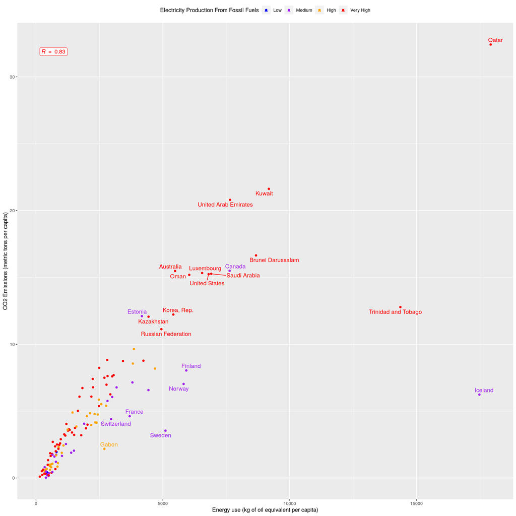

There appears to be a strong positive linear relationship, however we can immediately spot some interesting outliers. Qatar, Iceland, and Trinidad and Tobago are all conspicuously anomalous, and there seems to be some clear separation between nations that have over 10 metric tons of CO2 emissions per capita. Most of the countries in this group appear to be oil producing nations e.g. U.S., Russia, Canada and a few middle eastern countries. One of the nations that immediately pops out is Canada, when we look into the data Canada is producing 63% of it’s electricity from renewable energy sources, and the very high CO2 emissions seem to be accounted for by Canada’s petroleum production and in particular it’s use of tar sands for this purpose<sup>[1](https://news.stanford.edu/2018/08/30/measuring-crude-oils-carbon-footprint)</sup>. This highlights something interesting missing from the indicators we have available i.e. we have indicators for CO2 emissions from gaseous, liquid and solid fuel consumption, but there is no indicator for CO2 emissions from gas flaring (and potentially other high CO2 emitting activities of petroleum production). This data point could be useful to explain some of the variance within our dataset and it would be worth reviewing the results if it became available.

```r
wbcc_cln[wbcc_cln$iso3c=='CAN', c('country','EG.ELC.RNEW.ZS')]
```

```
##    country EG.ELC.RNEW.ZS
## 33  Canada       63.01145
```

Given the above, we should expect that energy use per capita (‘EG.USE.PCAP.KG.OE’) will also have a strong relationship with the total greenhouse gas emissions per capita (‘EN.ATM.GHGT.KT.PC’). From this, plus the interest we have in exploring what the relationship of different types of electricity production, it was decided that breaking down the energy use per capita to account for electricity consumption would be a good idea. The new predictors created for this were outlined in the data section above.

## 4.1 Data Exploration Using PCA

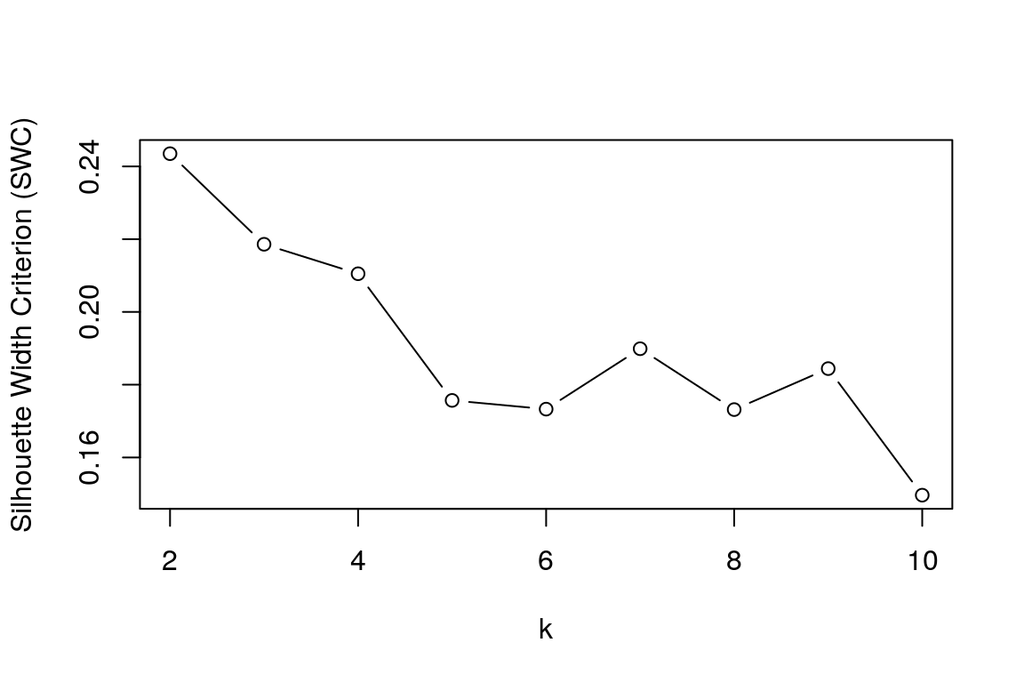

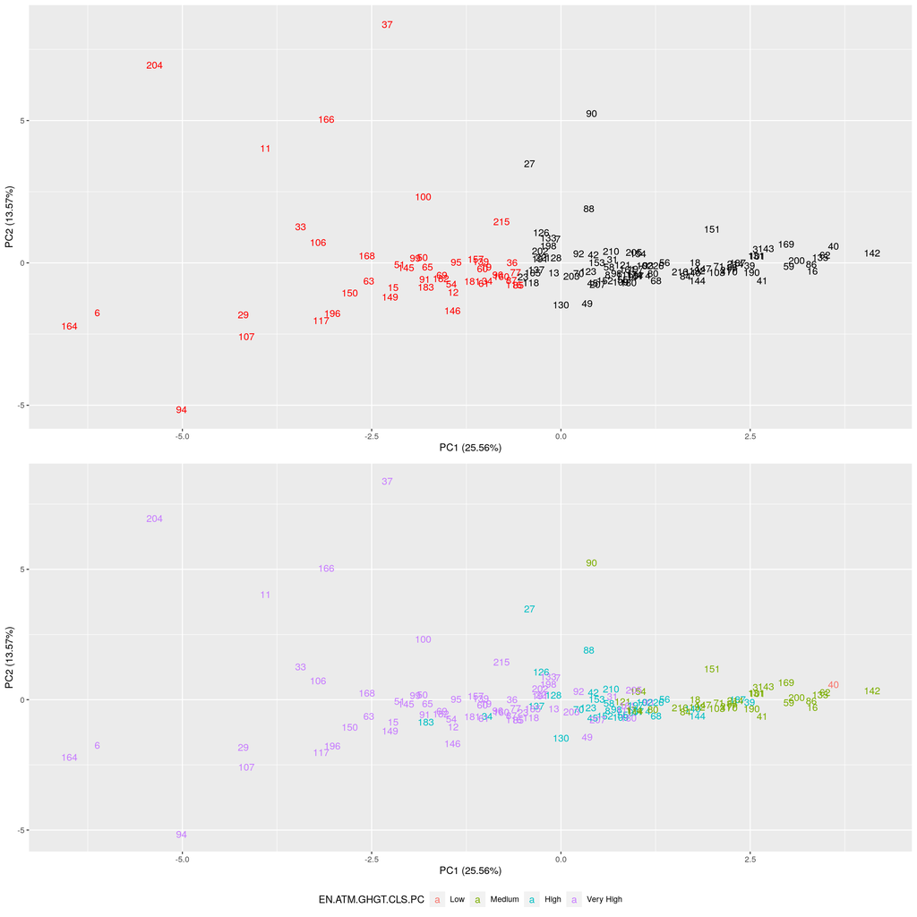

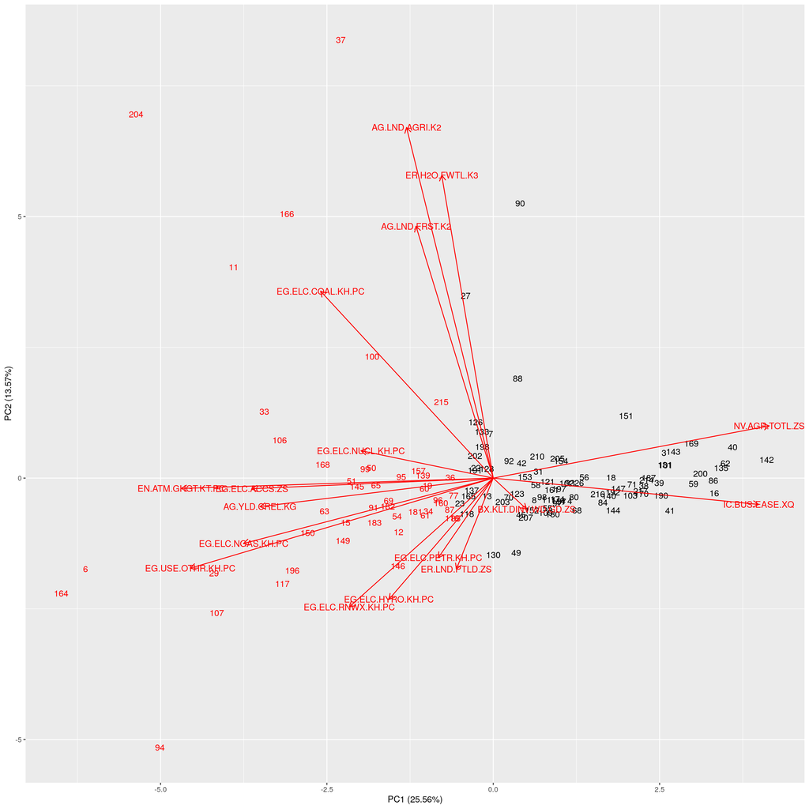

```r
wbcc_cln.lm <- lm(log(EN.ATM.GHGT.KT.PC) ~ log(EG.USE.OTHR.KH.PC) +
                    log(EG.ELC.COAL.KH.PC+1) + log(EG.ELC.NGAS.KH.PC+1) +
                    log(EG.ELC.NUCL.KH.PC+1) + log(EG.ELC.HYRO.KH.PC+1) +
                    log(EG.ELC.RNWX.KH.PC+1) + log(EG.ELC.PETR.KH.PC+1) +
                    EG.ELC.ACCS.ZS + log(AG.LND.AGRI.K2+1) + log(AG.LND.FRST.K2+1) +
                    AG.YLD.CREL.KG + NV.AGR.TOTL.ZS + I(1/ER.H2O.FWTL.K3) +
                    ER.LND.PTLD.ZS + IC.BUS.EASE.XQ + BX.KLT.DINV.WD.GD.ZS,
                  data=wbcc_cln)
summary(wbcc_cln.lm)
```

```
##
## Call:
## lm(formula = log(EN.ATM.GHGT.KT.PC) ~ log(EG.USE.OTHR.KH.PC) +
##     log(EG.ELC.COAL.KH.PC + 1) + log(EG.ELC.NGAS.KH.PC + 1) +
##     log(EG.ELC.NUCL.KH.PC + 1) + log(EG.ELC.HYRO.KH.PC + 1) +
##     log(EG.ELC.RNWX.KH.PC + 1) + log(EG.ELC.PETR.KH.PC + 1) +
##     EG.ELC.ACCS.ZS + log(AG.LND.AGRI.K2 + 1) + log(AG.LND.FRST.K2 +
##     1) + AG.YLD.CREL.KG + NV.AGR.TOTL.ZS + I(1/ER.H2O.FWTL.K3) +
##     ER.LND.PTLD.ZS + IC.BUS.EASE.XQ + BX.KLT.DINV.WD.GD.ZS, data = wbcc_cln)
##
## Residuals:
##      Min       1Q   Median       3Q      Max
## -1.01654 -0.14627  0.01402  0.16968  0.94267
##
## Coefficients:
##                              Estimate Std. Error t value Pr(>|t|)
## (Intercept)                -1.291e+01  6.935e-01 -18.615  < 2e-16 ***
## log(EG.USE.OTHR.KH.PC)      6.774e-01  5.605e-02  12.085  < 2e-16 ***
## log(EG.ELC.COAL.KH.PC + 1)  1.415e-02  8.031e-03   1.762 0.080704 .
## log(EG.ELC.NGAS.KH.PC + 1) -7.795e-03  7.885e-03  -0.989 0.324940
## log(EG.ELC.NUCL.KH.PC + 1) -1.640e-02  8.095e-03  -2.025 0.045189 *
## log(EG.ELC.HYRO.KH.PC + 1) -2.909e-02  1.206e-02  -2.413 0.017444 *
## log(EG.ELC.RNWX.KH.PC + 1) -2.830e-02  1.141e-02  -2.479 0.014648 *
## log(EG.ELC.PETR.KH.PC + 1)  1.565e-02  1.277e-02   1.226 0.222689
## EG.ELC.ACCS.ZS              9.584e-03  2.424e-03   3.953 0.000135 ***
## log(AG.LND.AGRI.K2 + 1)     2.792e-02  2.675e-02   1.044 0.298914
## log(AG.LND.FRST.K2 + 1)     3.049e-02  2.312e-02   1.319 0.189915
## AG.YLD.CREL.KG              1.750e-05  1.225e-05   1.429 0.155902
## NV.AGR.TOTL.ZS             -2.825e-03  6.309e-03  -0.448 0.655187
## I(1/ER.H2O.FWTL.K3)         8.758e-03  1.102e-02   0.795 0.428501
## ER.LND.PTLD.ZS              6.374e-04  3.153e-03   0.202 0.840174
## IC.BUS.EASE.XQ             -1.232e-03  1.053e-03  -1.169 0.244716
## BX.KLT.DINV.WD.GD.ZS       -8.899e-04  3.096e-03  -0.287 0.774274
## ---
## Signif. codes:  0 '***' 0.001 '**' 0.01 '*' 0.05 '.' 0.1 ' ' 1
##
## Residual standard error: 0.3485 on 113 degrees of freedom
## Multiple R-squared:  0.8543, Adjusted R-squared:  0.8337
## F-statistic: 41.42 on 16 and 113 DF,  p-value: < 2.2e-16
```

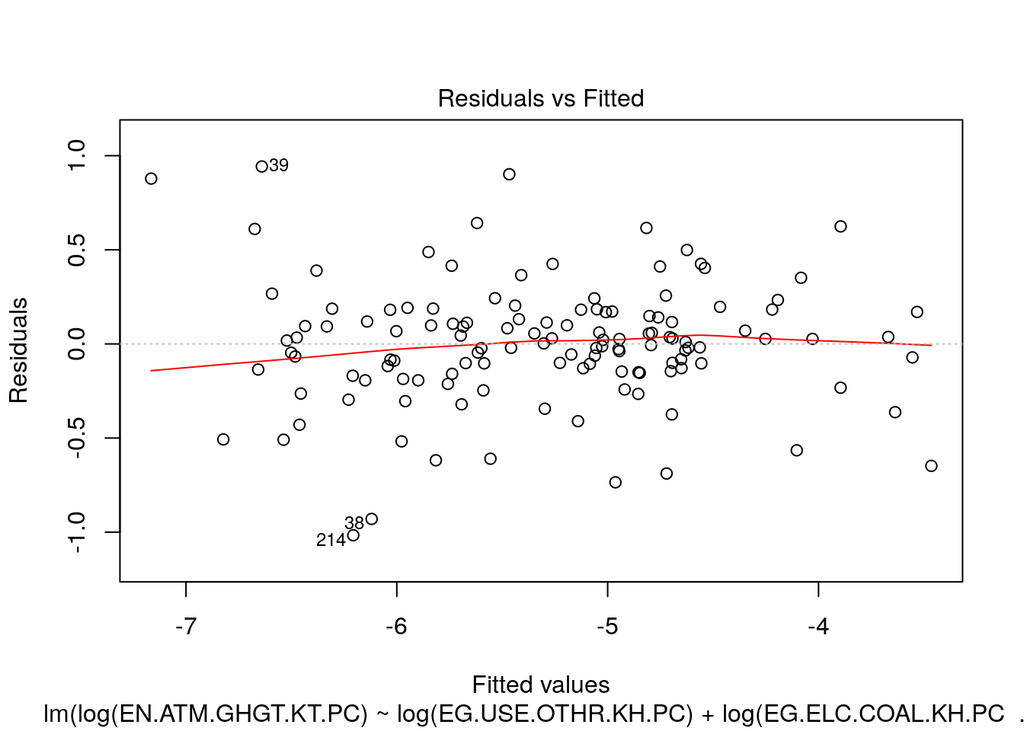

```r
plot(wbcc_cln.lm, which=1)
```

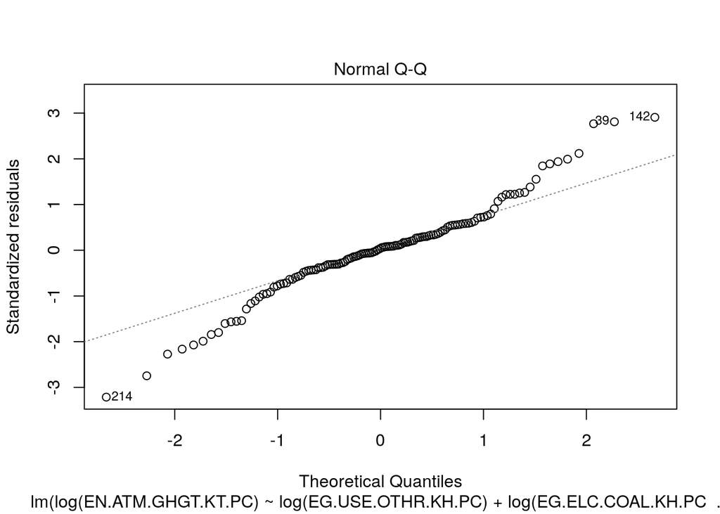

[output not shown]

[figure not shown]

[figure not shown]

```r
plot(wbcc_cln.lm, which=2)
```

```r
wbcc_cln.X <- model.matrix(wbcc_cln.lm)
wbcc_cln.Y <- log(wbcc_cln$EN.ATM.GHGT.KT.PC)
wbcc_cln.lm.lasso = glmnet(wbcc_cln.X, wbcc_cln.Y, alpha=1)
```

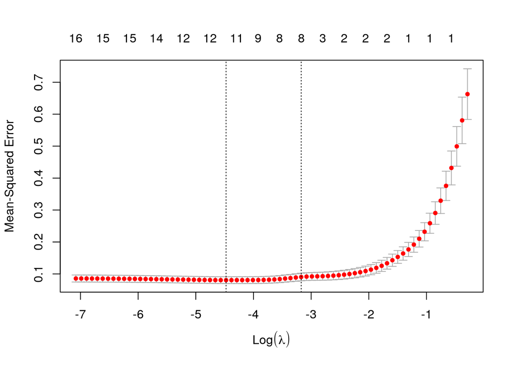

```r
wbcc_cln.lm.lasso.cv <- cv.glmnet(wbcc_cln.X, wbcc_cln.Y, alpha=1)
plot(wbcc_cln.lm.lasso.cv)
```

```r
wbcc_cln.lm.lasso.cv$lambda.min
```

```
## [1] 0.01139003
```

```r
wbcc_cln.lm.lasso.cv$lambda.1se
```

```
## [1] 0.04189686
```

```r
#wbcc_cln.lm.lasso.cv$lambda
coef(wbcc_cln.lm.lasso.cv, s=wbcc_cln.lm.lasso.cv$lambda.min)
```

```
## 18 x 1 sparse Matrix of class "dgCMatrix"
##                                       s1
## (Intercept)                -1.342998e+01
## (Intercept)                 .
## log(EG.USE.OTHR.KH.PC)      7.438272e-01
## log(EG.ELC.COAL.KH.PC + 1)  3.254920e-03
## log(EG.ELC.NGAS.KH.PC + 1) -3.208196e-03
## log(EG.ELC.NUCL.KH.PC + 1) -1.336619e-02
## log(EG.ELC.HYRO.KH.PC + 1) -1.288477e-02
## log(EG.ELC.RNWX.KH.PC + 1) -1.575919e-02
## log(EG.ELC.PETR.KH.PC + 1)  5.772375e-03
## EG.ELC.ACCS.ZS              9.405497e-03
## log(AG.LND.AGRI.K2 + 1)     3.282967e-02
## log(AG.LND.FRST.K2 + 1)     6.625995e-03
## AG.YLD.CREL.KG              7.659400e-07
## NV.AGR.TOTL.ZS             -6.662773e-03
## I(1/ER.H2O.FWTL.K3)         .
## ER.LND.PTLD.ZS              .
## IC.BUS.EASE.XQ              .
## BX.KLT.DINV.WD.GD.ZS        .
```

```r
coef(wbcc_cln.lm.lasso.cv,)
```

```
## 18 x 1 sparse Matrix of class "dgCMatrix"
##                                       s1
## (Intercept)                -1.267444e+01
## (Intercept)                 .
## log(EG.USE.OTHR.KH.PC)      7.093109e-01
## log(EG.ELC.COAL.KH.PC + 1)  .
## log(EG.ELC.NGAS.KH.PC + 1)  .
## log(EG.ELC.NUCL.KH.PC + 1) -2.152128e-03
## log(EG.ELC.HYRO.KH.PC + 1) -4.942828e-03
## log(EG.ELC.RNWX.KH.PC + 1) -2.582713e-04
## log(EG.ELC.PETR.KH.PC + 1)  5.381211e-04
## EG.ELC.ACCS.ZS              6.599600e-03
## log(AG.LND.AGRI.K2 + 1)     5.132593e-03
## log(AG.LND.FRST.K2 + 1)     .
## AG.YLD.CREL.KG              .
## NV.AGR.TOTL.ZS             -2.151656e-03
## I(1/ER.H2O.FWTL.K3)         .
## ER.LND.PTLD.ZS              .
## IC.BUS.EASE.XQ              .
## BX.KLT.DINV.WD.GD.ZS        .
```

```r
wbcc_cln.lm <- lm(log(EN.ATM.GHGT.KT.PC) ~ log(EG.USE.OTHR.KH.PC) +
                    log(EG.ELC.COAL.KH.PC+1) + log(EG.ELC.NGAS.KH.PC+1) +
                    log(EG.ELC.NUCL.KH.PC+1) + log(EG.ELC.HYRO.KH.PC+1) +
                    log(EG.ELC.RNWX.KH.PC+1) + log(EG.ELC.PETR.KH.PC+1) +
                    EG.ELC.ACCS.ZS + NV.AGR.TOTL.ZS + log(AG.LND.AGRI.K2+1),
                  data=wbcc_cln)
summary(wbcc_cln.lm)
```

```
##
## Call:
## lm(formula = log(EN.ATM.GHGT.KT.PC) ~ log(EG.USE.OTHR.KH.PC) +
##     log(EG.ELC.COAL.KH.PC + 1) + log(EG.ELC.NGAS.KH.PC + 1) +
##     log(EG.ELC.NUCL.KH.PC + 1) + log(EG.ELC.HYRO.KH.PC + 1) +
##     log(EG.ELC.RNWX.KH.PC + 1) + log(EG.ELC.PETR.KH.PC + 1) +
##     EG.ELC.ACCS.ZS + NV.AGR.TOTL.ZS + log(AG.LND.AGRI.K2 + 1),
##     data = wbcc_cln)
##
## Residuals:
##      Min       1Q   Median       3Q      Max
## -0.64471 -0.16228 -0.02188  0.13997  0.69527
##
## Coefficients:
##                              Estimate Std. Error t value Pr(>|t|)
## (Intercept)                -13.878375   0.509091 -27.261  < 2e-16 ***
## log(EG.USE.OTHR.KH.PC)       0.774371   0.045482  17.026  < 2e-16 ***
## log(EG.ELC.COAL.KH.PC + 1)   0.006678   0.005789   1.154 0.251177
## log(EG.ELC.NGAS.KH.PC + 1)  -0.010670   0.006094  -1.751 0.082739 .
## log(EG.ELC.NUCL.KH.PC + 1)  -0.017653   0.005997  -2.944 0.003959 **
## log(EG.ELC.HYRO.KH.PC + 1)  -0.013690   0.008142  -1.681 0.095545 .
## log(EG.ELC.RNWX.KH.PC + 1)  -0.021994   0.007346  -2.994 0.003402 **
## log(EG.ELC.PETR.KH.PC + 1)   0.007112   0.008610   0.826 0.410597
## EG.ELC.ACCS.ZS               0.010647   0.001683   6.326 5.56e-09 ***
## NV.AGR.TOTL.ZS              -0.008114   0.004961  -1.635 0.104813
## log(AG.LND.AGRI.K2 + 1)      0.052285   0.014842   3.523 0.000623 ***
## ---
## Signif. codes:  0 '***' 0.001 '**' 0.01 '*' 0.05 '.' 0.1 ' ' 1
##
## Residual standard error: 0.2575 on 110 degrees of freedom
## Multiple R-squared:  0.909,  Adjusted R-squared:  0.9007
## F-statistic: 109.9 on 10 and 110 DF,  p-value: < 2.2e-16
```

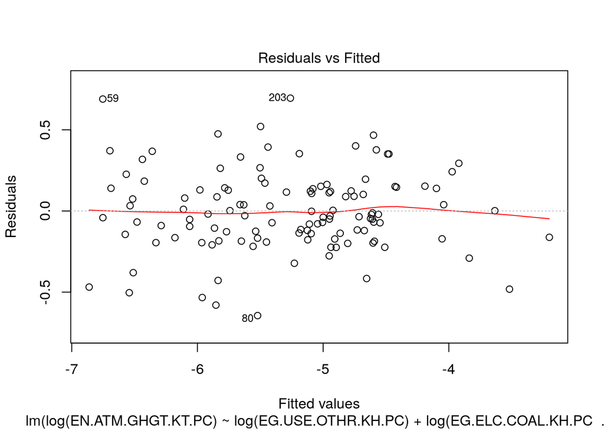

```r
plot(wbcc_cln.lm, which=1)
```

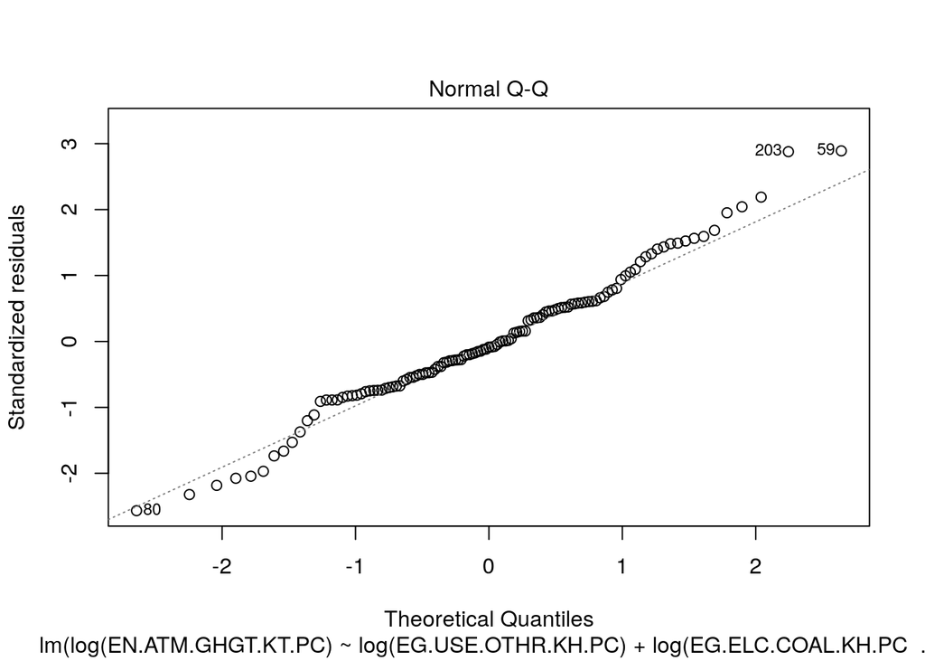

```r
plot(wbcc_cln.lm, which=2)
```

# 5 **Results and Discussion**

# 6 **Conclusions**

# 7 **References**

1. [Stanford study finds stark differences in the carbon-intensity of global oil fields (Josie Garthwaite)](https://news.stanford.edu/2018/08/30/measuring-crude-oils-carbon-footprint)

# 8 **Appendix A**

```r
q <- quantile(wbcc_cln$EN.ATM.GHGT.KT.PC, probs=seq(0, 1, 0.5))
wbcc_cln$EN.ATM.GHGT.CLS.PC <- ifelse(wbcc_cln$EN.ATM.GHGT.KT.PC <= q[2], 'Low', 'High')
wbcc_cln$EN.ATM.GHGT.CLS.PC <- factor(wbcc_cln$EN.ATM.GHGT.CLS.PC, levels=c('Low', 'High'))

numeric_predictors <- c("EG.USE.OTHR.KH.PC", "EG.ELC.COAL.KH.PC", "EG.ELC.NGAS.KH.PC",
                        "EG.ELC.NUCL.KH.PC", "EG.ELC.HYRO.KH.PC", "EG.ELC.RNWX.KH.PC",
                        "EG.ELC.ACCS.ZS", "NV.AGR.TOTL.ZS", "AG.LND.AGRI.K2")
predictors <- wbcc_cln[,numeric_predictors]        # data for numeric predictors
class <- wbcc_cln[,"EN.ATM.GHGT.CLS.PC"]              # class labels (response)
predictors_and_class <- wbcc_cln[,c(numeric_predictors, "EN.ATM.GHGT.CLS.PC")]

qda.fit <- qda(EN.ATM.GHGT.CLS.PC~., data=predictors_and_class, CV=T)  # CV=True performs LOOCV
( qda.cm <- table(qda.fit$class, predictors_and_class$EN.ATM.GHGT.CLS.PC) )   # create confusion matrix
```

```
##
##        Low High
##   Low   54    8
##   High   7   52
```

```r
( qda.accuracy <- sum(diag(qda.cm))/sum(qda.cm) )  # calculate model accuracy
```

```
## [1] 0.8760331
```

```r
( qda.error <- 1-qda.accuracy )                    # calculate model error
```

```
## [1] 0.1239669
```

```r
qda.n = sum(qda.cm)                  # total no. observations
qda.diag = diag(qda.cm)              # number of correctly classified instances per class
qda.rowsums = apply(qda.cm, 1, sum)  # number of instances per class
qda.colsums = apply(qda.cm, 2, sum)  # number of predictions per class
(qda.precision = qda.diag / qda.colsums)
```

```
##       Low      High
## 0.8852459 0.8666667
```

```r
(qda.recall = qda.diag / qda.rowsums)
```

```
##       Low      High
## 0.8709677 0.8813559
```

```r
(qda.f1 = 2 * qda.precision * qda.recall / (qda.precision + qda.recall))
```

```
##       Low      High
## 0.8780488 0.8739496
```

# 9 **Appendix B**

## 9.1 Part I Count of missing values by indicator variable

```r
wbcc <- read.csv("wbcc_bc.csv", stringsAsFactors=T)
# get a count of the number of missing values in each column
wbcc_na_count <- data.frame(sapply(wbcc, function(y) length(which(is.na(y)))))
# get the variable names
variables <- rownames(wbcc_na_count)
# get the counts
na_count <- wbcc_na_count$sapply.wbcc..function.y..length.which.is.na.y....
# create a data frame using the variable names and counts from above
wbcc_na_count <- data.frame(variables, na_count)
# sort them by count of missing value (desc)
wbcc_na_count_sorted <- wbcc_na_count[order(wbcc_na_count$na_count, decreasing=T),]
# show the variables with counts > 100
head(wbcc_na_count_sorted, 20)
```

```
##            variables na_count
## 67    IS.ROD.PAVE.ZS      166
## 72    SH.MED.CMHW.P3      157
## 54 EN.CLC.GHGR.MT.CE      155
## 53    EN.CLC.DRSK.XQ      134
## 66    IQ.CPA.PUBS.XQ      130
## 59 EN.URB.MCTY.TL.ZS       96
## 13 AG.LND.IRIG.AG.ZS       93
## 46 EN.ATM.HFCG.KT.CE       80
## 51 EN.ATM.PFCG.KT.CE       80
## 52 EN.ATM.SF6G.KT.CE       80
## 18    EG.ELC.COAL.ZS       76
## 19    EG.ELC.HYRO.ZS       76
## 20    EG.ELC.NGAS.ZS       76
## 21    EG.ELC.NUCL.ZS       76
## 22    EG.ELC.PETR.ZS       76
## 24    EG.ELC.RNWX.KH       76
## 25    EG.ELC.RNWX.ZS       76
## 28 EG.USE.ELEC.KH.PC       75
## 73    SH.STA.MALN.ZS       67
## 74       SI.POV.DDAY       55
```

## 9.2 Part II Removal of indicators

These indicators related to land use and agriculture were removed because they were considered to unrelated or duplicating measures already present:

| Indicator | Description |
| --- | --- |
| AG.LND.AGRI.ZS | Agricultural land (% of land area) |
| AG.LND.ARBL.ZS | Arable land (% of land area) |
| AG.LND.EL5M.RU.K2 | Rural land area where elevation is below 5 meters (sq. km) |
| AG.LND.EL5M.RU.ZS | Rural land area where elevation is below 5 meters (% of total land area) |
| AG.LND.EL5M.UR.K2 | Urban land area where elevation is below 5 meters (sq. km) |
| AG.LND.EL5M.UR.ZS | Urban land area where elevation is below 5 meters (% of total land area) |
| AG.LND.EL5M.ZS | Land area where elevation is below 5 meters (% of total land area) |
| AG.LND.FRST.ZS | Forest area (% of land area) |
| AG.LND.PRCP.MM | Average precipitation in depth (mm per year) |

These indicators related to energy generation and consumption that were removed because they were considered to be duplicating measures already present. E.g. for electric power consumption (kWh per capita) (‘EG.USE.ELEC.KH.PC’), this was highly correlated with energy use (kg of oil equivalent per capita) (‘EG.USE.PCAP.KG.OE’) and one would expect electric power consumption to be a subset of total energy consumption:

| Indicator | Description |
| --- | --- |
| EG.ELC.COAL.ZS | Electricity production from coal sources (% of total) |
| EG.ELC.HYRO.ZS | Electricity production from hydroelectric sources (% of total) |
| EG.ELC.NGAS.ZS | Electricity production from natural gas sources (% of total) |
| EG.ELC.NUCL.ZS | Electricity production from nuclear sources (% of total) |
| EG.ELC.PETR.ZS | Electricity production from oil sources (% of total) |
| EG.ELC.RNWX.ZS | Electricity production from renewable sources, excluding hydroelectric (% of total) |
| EG.ELC.RNEW.ZS | Renewable electricity output (% of total electricity output) |
| EG.ELC.RNWX.KH | Electricity production from renewable sources, excluding hydroelectric (kWh) |
| EG.FEC.RNEW.ZS | Renewable energy consumption (% of total final energy consumption) |
| EG.USE.COMM.GD.PP.KD | Energy use (kg of oil equivalent) per $1,000 GDP (constant 2017 PPP) |
| EG.USE.ELEC.KH.PC | Electric power consumption (kWh per capita) |

Since the response variable used was based on the total greenhouse gas emissions, these indicators related to emissions were removed because they were encapsulated by the response variable:

| Indicator | Description |
| --- | --- |
| EN.ATM.CO2E.EG.ZS | CO2 intensity (kg per kg of oil equivalent energy use) |
| EN.ATM.CO2E.GF.KT | CO2 emissions from gaseous fuel consumption (kt) |
| EN.ATM.CO2E.GF.ZS | CO2 emissions from gaseous fuel consumption (% of total) |
| EN.ATM.CO2E.KD.GD | CO2 emissions (kg per 2010 US$ of GDP) |
| EN.ATM.CO2E.LF.KT | CO2 emissions from liquid fuel consumption (kt) |
| EN.ATM.CO2E.LF.ZS | CO2 emissions from liquid fuel consumption (% of total) |
| EN.ATM.CO2E.PC | CO2 emissions (metric tons per capita) |
| EN.ATM.CO2E.PP.GD | CO2 emissions (kg per PPP $ of GDP) |
| EN.ATM.CO2E.PP.GD.KD | CO2 emissions (kg per 2017 PPP $ of GDP) |
| EN.ATM.CO2E.SF.KT | CO2 emissions from solid fuel consumption (kt) |
| EN.ATM.CO2E.SF.ZS | CO2 emissions from solid fuel consumption (% of total) |
| EN.ATM.GHGO.ZG | Other greenhouse gas emissions (% change from 1990) |
| EN.ATM.GHGT.ZG | Total greenhouse gas emissions (% change from 1990) |
| EN.ATM.HFCG.KT.CE | HFC gas emissions (thousand metric tons of CO2 equivalent) |
| EN.ATM.METH.KT.CE | Methane emissions (kt of CO2 equivalent) |
| EN.ATM.METH.ZG | Methane emissions (% change from 1990) |
| EN.ATM.NOXE.KT.CE | Nitrous oxide emissions (thousand metric tons of CO2 equivalent) |
| EN.ATM.NOXE.ZG | Nitrous oxide emissions (% change from 1990) |
| EN.ATM.PFCG.KT.CE | PFC gas emissions (thousand metric tons of CO2 equivalent) |
| EN.ATM.SF6G.KT.CE | SF6 gas emissions (thousand metric tons of CO2 equivalent) |
| EN.CLC.GHGR.MT.CE | GHG net emissions/removals by LUCF (Mt of CO2 equivalent) |

Indicators related to education and health were considered unrelated to emissions and removed:

| Indicator | Description |
| --- | --- |
| SE.ENR.PRSC.FM.ZS | School enrollment, primary and secondary (gross), gender parity index (GPI) |
| SE.PRM.CMPT.ZS | Primary completion rate, total (% of relevant age group) |
| SH.DYN.MORT | Mortality rate, under-5 (per 1,000 live births) |
| SH.MED.CMHW.P3 | Community health workers (per 1,000 people) |
| SH.STA.MALN.ZS | Prevalence of underweight, weight for age (% of children under 5) |
| SI.POV.DDAY | Poverty headcount ratio at $1.90 a day (2011 PPP) (% of population) |

Indicators related to population were removed since per capita measures were used:

| Indicator | Description |
| --- | --- |
| SP.POP.GROW | Population growth (annual %) |
| SP.URB.GROW | Urban population growth (annual %) |
| SP.URB.TOTL | Urban population |
| SP.URB.TOTL.IN.ZS | Urban population (% of total population) |
| EN.POP.EL5M.RU.ZS | Rural population living in areas where elevation is below 5 meters (% of total population) |
| EN.POP.EL5M.UR.ZS | Urban population living in areas where elevation is below 5 meters (% of total population) |
| EN.POP.EL5M.ZS | Population living in areas where elevation is below 5 meters (% of total population) |
| EN.URB.MCTY.TL.ZS | Population in urban agglomerations of more than 1 million (% of total population) |

Miscellaneous indicators considered unrelated to emissions:

| Indicator | Description |
| --- | --- |
| EN.CLC.DRSK.XQ | Disaster risk reduction progress score (1-5 scale; 5=best) |
| ER.H2O.FWTL.ZS | Annual freshwater withdrawals, total (% of internal resources) |
| ER.MRN.PTMR.ZS | Marine protected areas (% of territorial waters) |
| ER.PTD.TOTL.ZS | Terrestrial and marine protected areas (% of total territorial area) |
| IQ.CPA.PUBS.XQ | CPIA public sector management and institutions cluster average (1=low to 6=high) |
| IS.ROD.PAVE.ZS | Roads, paved (% of total roads) |